# Predictors of frog survival following translocations - supplemental analyses

Roland Knapp

The following are supplemental analyses, some related to analyses in `translocation_survival_analysis.Rmd` and some unrelated.

## Load packages

```r
library(RPostgreSQL)
library(tidyverse)
library(lubridate)
library(brms)
library(rstanarm)
library(bayesplot)
library(tidybayes)
library(loo)
library(broom.mixed)
library(janitor)

source("classification_summary.R")
```

## ANALYSIS 1: Analysis of changes in Bd load following translocation

- Compare loads at time of translocation to those from CMR years 0 and 1. Exclude years > 1. Only frogs that were recaptured at least once following translocation are included.
- Model with pit_tag_ref as grouping variable is the model of primary interest, roughly analogous to paired t-test. Included other models to allow a better understanding of the data.

### Read in frog-Bd dataset

```r
d1 <- read_csv(here::here("data", "clean", "bd_beforeafter_translocation.csv"))
```

- site_id: Unique 5-digit site identifier.
- site_id1: Assigned 5-digit site identifier for a collection of adjacent sites that are utilized by a frog population.
- translocation_id: Unique identifier for each translocation.
- visit_date: Date on which translocation or survey was conducted.
- survey_type: “translocation” or “cmr”.
- period: “before” or “after” translocation.
- year_translocate: Year in which translocation was conducted.
- year_capture: Year in which frog was captured.
- interval: Number of years between translocation and frog capture.
- pit_tag_ref: Unique PIT tag identifier.
- swab_id: Unique identifier for skin swab sample.
- bd_load: Bd infection intensity determined from skin swab samples, units are number of ITS1 copies * 80.

### Data exploration

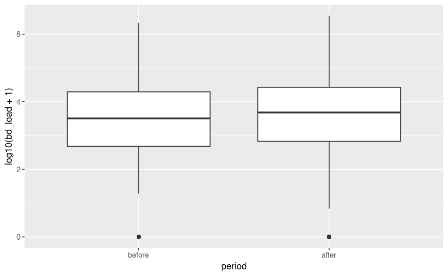

```r
d1 %>%
  mutate(period = factor(period, levels = c("before", "after"))) %>%
  ggplot(aes(x = period, y = log10(bd_load + 1))) +
          geom_boxplot()
```

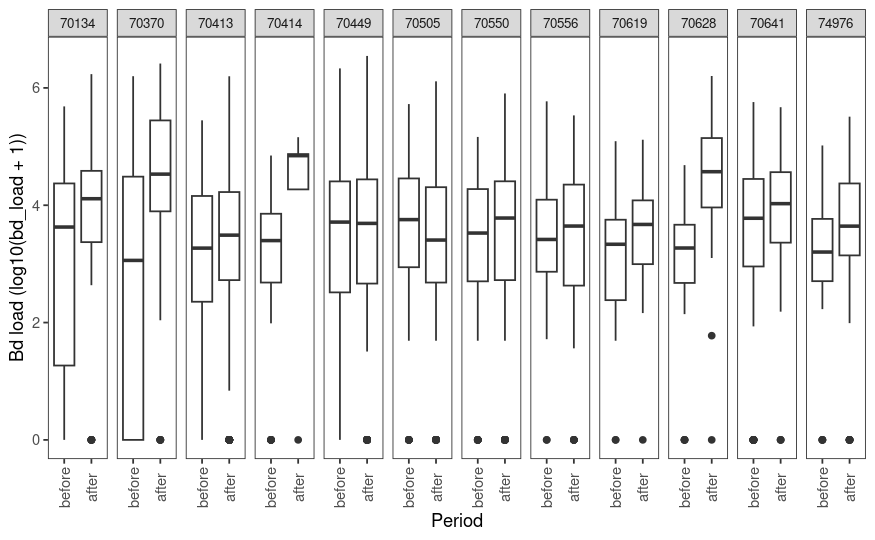

```r
d1 %>%
  mutate(period = factor(period, levels = c("before", "after"))) %>%
  ggplot(aes(x = period, y = log10(bd_load + 1))) +
    geom_boxplot() +
    labs(x = "Period", y = "Bd load (log10(bd_load + 1))") +
    facet_grid(. ~ site_id1) +
    theme_bw() +
    theme(axis.text.x = element_text(angle = 90, vjust = 0.5),
          strip.text.x = element_text(size = 8),
          panel.grid = element_blank())
ggsave(here::here("doc", "manuscript", "figures", "bdload_beforeafter.png"), width = 6, height = 3)
```

- In most cases, relatively small increases in load following translocation.

### Prepare variables for analysis

```r
d1 <- d1 %>%
  mutate(after = if_else(period == "after", 1, 0),
         bd_load = as.integer(round(bd_load)),
         after_c = after - mean(after))
```

### Check for null values

```r
d1 %>% summarize(across(everything(), ~ sum(is.na(.))))
```

| site_id | site_id1 | translocation_id | visit_date | survey_type | period | year_translocate | year_capture | interval | pit_tag_ref | swab_id | bd_load | after | after_c |
| --- | --- | --- | --- | --- | --- | --- | --- | --- | --- | --- | --- | --- | --- |
| 0 | 0 | 0 | 0 | 0 | 0 | 0 | 0 | 0 | 0 | 0 | 0 | 0 | 0 |

### Include only CMR years 0 and 1

```r
d2 <- d1 %>%
  filter(interval < 2)
```

### Plot distribution of bd_load response variable

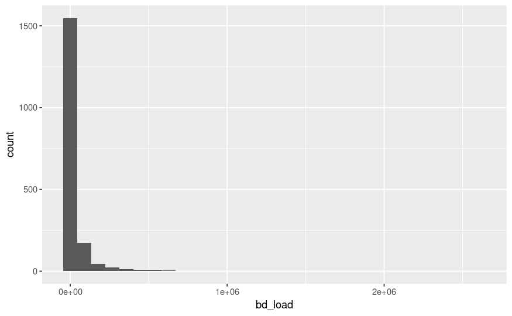

```r
d2 %>%
  ggplot(aes(x = bd_load)) +
    geom_histogram()
```

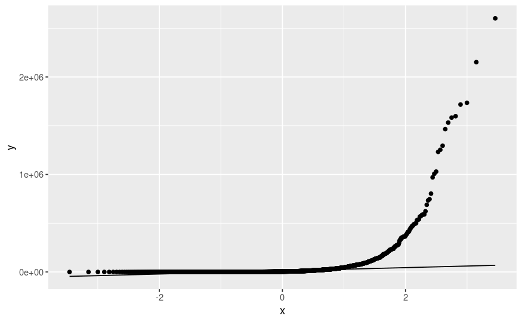

```r
d2 %>%
  ggplot(aes(sample = bd_load)) +
    geom_qq() +
    geom_qq_line()
```

### Model without group-level effects

#### Model specification

```r
m1a <- stan_glm(
  bd_load ~ after_c,
  data = d2,
  family = neg_binomial_2(),
  chains = 4,
  iter = 5000*2,
  cores = 4,
  seed = 84735)
```

```
starting worker pid=44660 on localhost:11146 at 21:50:25.710
starting worker pid=44689 on localhost:11146 at 21:50:25.833
starting worker pid=44718 on localhost:11146 at 21:50:25.962
starting worker pid=44747 on localhost:11146 at 21:50:26.093
```

#### Priors and chain diagnostics

```r
prior_summary(m1a)
```

```
Priors for model 'm1a'
------
Intercept (after predictors centered)
 ~ normal(location = 0, scale = 2.5)

Coefficients
  Specified prior:
    ~ normal(location = 0, scale = 2.5)
  Adjusted prior:
    ~ normal(location = 0, scale = 5.1)

Auxiliary (reciprocal_dispersion)
 ~ exponential(rate = 1)
------
See help('prior_summary.stanreg') for more details
```

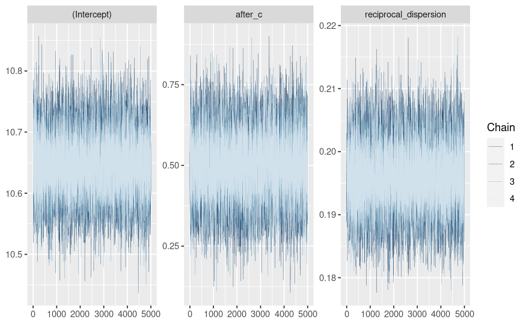

```r
mcmc_trace(m1a, size = 0.1)
```

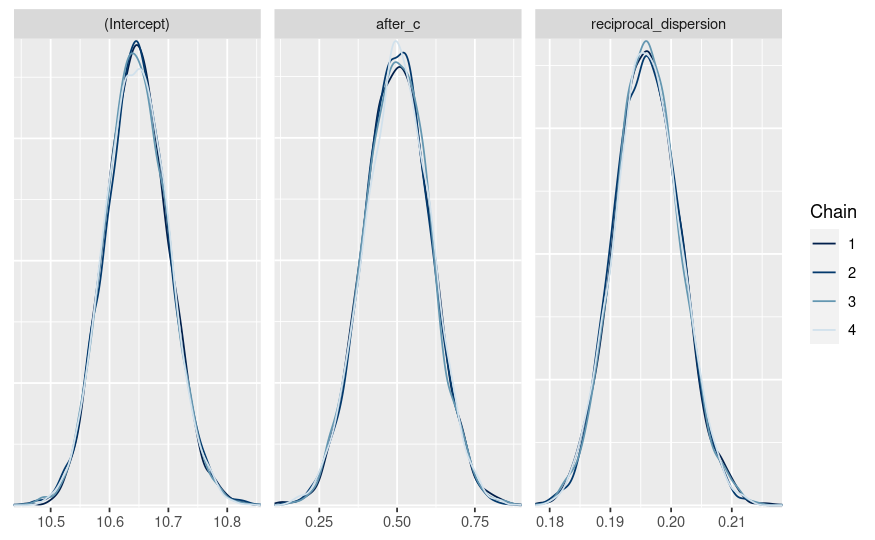

```r
mcmc_dens_overlay(m1a)
```

```r
summary(m1a)
```

```
Model Info:
 function:     stan_glm
 family:       neg_binomial_2 [log]
 formula:      bd_load ~ after_c
 algorithm:    sampling
 sample:       20000 (posterior sample size)
 priors:       see help('prior_summary')
 observations: 1841
 predictors:   2

Estimates:
                        mean   sd   10%   50%   90%
(Intercept)           10.6    0.1 10.6  10.6  10.7
after_c                0.5    0.1  0.4   0.5   0.6
reciprocal_dispersion  0.2    0.0  0.2   0.2   0.2

Fit Diagnostics:
           mean    sd      10%     50%     90%
mean_PPD 42105.5  3260.0 38030.5 41975.3 46299.2

The mean_ppd is the sample average posterior predictive distribution of the outcome variable (for details see help('summary.stanreg')).

MCMC diagnostics
                      mcse Rhat n_eff
(Intercept)            0.0  1.0 21050
after_c                0.0  1.0 21464
reciprocal_dispersion  0.0  1.0 22085
mean_PPD              23.0  1.0 20063
log-posterior          0.0  1.0  8641

For each parameter, mcse is Monte Carlo standard error, n_eff is a crude measure of effective sample size, and Rhat is the potential scale reduction factor on split chains (at convergence Rhat=1).
```

#### Posterior predictive check

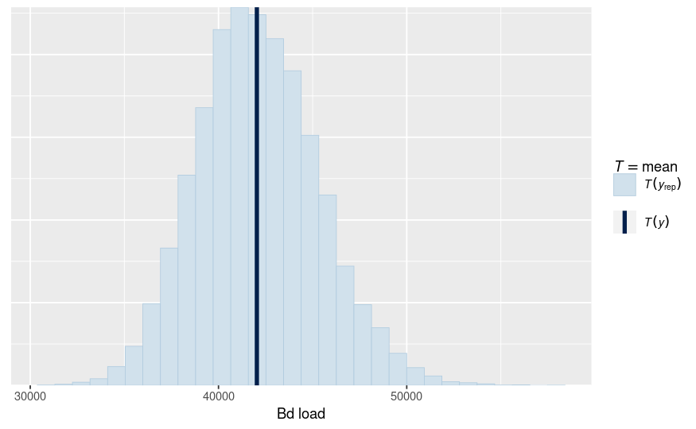

```r
pp_check(m1a, plotfun = "stat") +
    xlab("Bd load")
```

- Posterior predictive distribution implied by regression model closely matches original data (based on mean Bd load).

#### Calculate loo

```r
loo_m1a <- loo(m1a, cores = 4, save_psis = TRUE)
print(loo_m1a)
```

```
Computed from 20000 by 1841 log-likelihood matrix
```

|  | Estimate | SE |
| --- | --- | --- |
| elpd_loo | -18450.3 | 155.8 |
| p_loo | 7.0 | 1.8 |
| looic | 36900.6 | 311.5 |

```
------
Monte Carlo SE of elpd_loo is 0.0.

All Pareto k estimates are good (k < 0.5).
See help('pareto-k-diagnostic') for details.
```

#### Posterior analysis

```r
tidy(m1a, conf.int = TRUE, conf.level = 0.90)
```

| term | estimate | std.error | conf.low | conf.high |
| --- | --- | --- | --- | --- |
| (Intercept) | 10.6458077 | 0.05353733 | 10.5607462 | 10.735268 |
| after_c | 0.5011399 | 0.10744380 | 0.3246766 | 0.678067 |

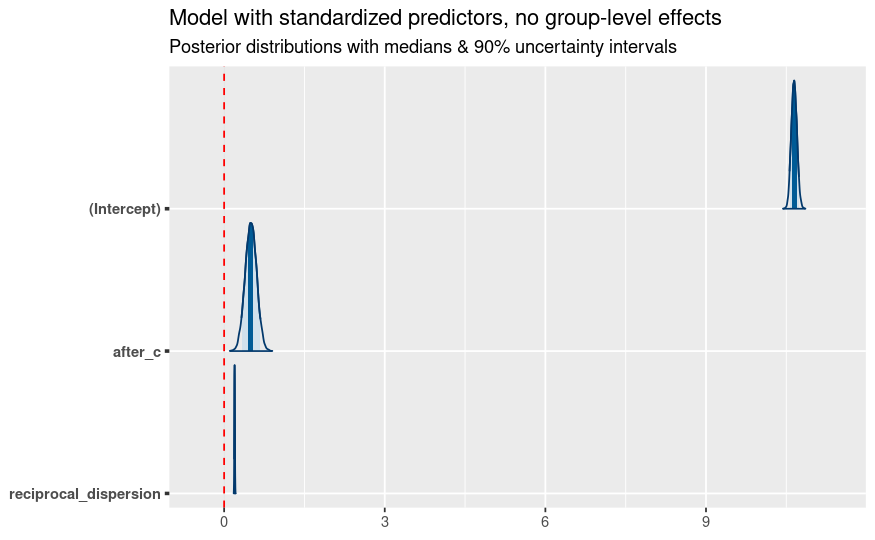

```r
mcmc_areas(m1a, area_method = "equal height", prob = 0.90) +
  geom_vline(xintercept = 0, color = "red", linetype = "dashed", lwd = 0.5) +
  ggtitle("Model with standardized predictors, no group-level effects",
          "Posterior distributions with medians & 90% uncertainty intervals")
```

```r
# mean(bayes_R2(m1a))   # bayes_R2 not available for negative binomials models in stanreg.
```

### Model with 1 grouping variable: pit_tag_ref

#### Model specification

```r
m1b <- stan_glmer(
  bd_load ~ after_c + (1 | pit_tag_ref),
  data = d2,
  family = neg_binomial_2(),
  chains = 4,
  iter = 5000*2,
  cores = 4,
  seed = 84735)
```

```
starting worker pid=45064 on localhost:11146 at 21:51:29.147
starting worker pid=45093 on localhost:11146 at 21:51:29.270
starting worker pid=45122 on localhost:11146 at 21:51:29.393
starting worker pid=45151 on localhost:11146 at 21:51:29.516
```

#### List model variable names

```r
get_variables(m1b)
```

[output not shown]

[output cut: 96 more lines]

#### Priors and chain diagnostics

```r
prior_summary(m1b)
```

```
Priors for model 'm1b'
------
Intercept (after predictors centered)
 ~ normal(location = 0, scale = 2.5)

Coefficients
  Specified prior:
    ~ normal(location = 0, scale = 2.5)
  Adjusted prior:
    ~ normal(location = 0, scale = 5.1)

Auxiliary (reciprocal_dispersion)
 ~ exponential(rate = 1)

Covariance
 ~ decov(reg. = 1, conc. = 1, shape = 1, scale = 1)
------
See help('prior_summary.stanreg') for more details
```

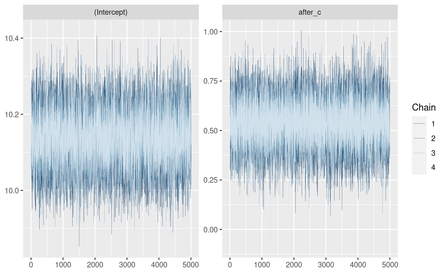

```r
b1 <- c("(Intercept)", "after_c")

mcmc_trace(m1b, size = 0.1, pars = b1)
```

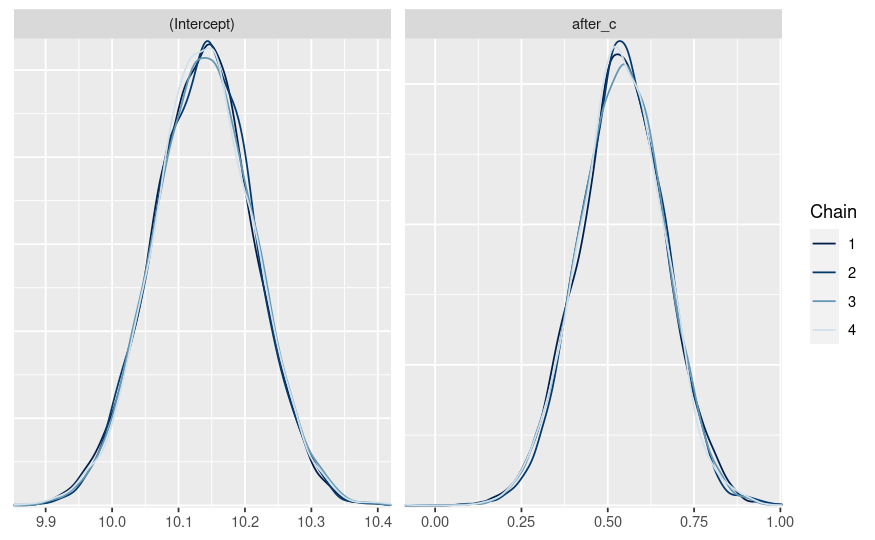

```r
mcmc_dens_overlay(m1b, pars = b1)
```

```r
summary(m1b)
```

```
Model Info:
 function:     stan_glmer
 family:       neg_binomial_2 [log]
 formula:      bd_load ~ after_c + (1 | pit_tag_ref)
 algorithm:    sampling
 sample:       20000 (posterior sample size)
 priors:       see help('prior_summary')
 observations: 1841
 groups:       pit_tag_ref (767)

Estimates:
                                             mean   sd   10%   50%   90%
(Intercept)                                10.1    0.1 10.0  10.1  10.2
after_c                                     0.5    0.1  0.4   0.5   0.7
b[(Intercept) pit_tag_ref:062374570]        0.6    0.7 -0.2   0.5   1.4
b[(Intercept) pit_tag_ref:080045534]       -0.4    0.8 -1.3  -0.4   0.7
b[(Intercept) pit_tag_ref:080045779]       -0.2    1.0 -1.4  -0.2   1.1
b[(Intercept) pit_tag_ref:080047783]       -0.2    1.0 -1.5  -0.2   1.2
b[(Intercept) pit_tag_ref:080048769]        1.0    0.6  0.2   0.9   1.8
b[(Intercept) pit_tag_ref:080048850]        0.2    0.9 -0.9   0.2   1.4
b[(Intercept) pit_tag_ref:080050269]       -0.4    0.9 -1.6  -0.5   0.8
b[(Intercept) pit_tag_ref:080050325]        0.5    0.8 -0.5   0.4   1.5
b[(Intercept) pit_tag_ref:080051294]       -0.2    0.8 -1.2  -0.2   0.9
b[(Intercept) pit_tag_ref:080052585]        0.1    0.7 -0.8   0.1   1.1
b[(Intercept) pit_tag_ref:080053099]       -0.2    1.0 -1.5  -0.2   1.1
b[(Intercept) pit_tag_ref:080054113]       -0.5    0.9 -1.5  -0.5   0.7
b[(Intercept) pit_tag_ref:080054873]        0.4    0.8 -0.7   0.3   1.5
b[(Intercept) pit_tag_ref:080055025]       -0.1    1.0 -1.4  -0.2   1.1
b[(Intercept) pit_tag_ref:080055046]        1.4    0.7  0.6   1.4   2.4
b[(Intercept) pit_tag_ref:080055334]        0.4    0.7 -0.6   0.3   1.3
b[(Intercept) pit_tag_ref:080058043]       -0.5    1.1 -1.9  -0.5   0.8
b[(Intercept) pit_tag_ref:080058318]       -0.7    1.0 -2.0  -0.7   0.6
b[(Intercept) pit_tag_ref:080058516]       -0.3    1.1 -1.6  -0.3   1.1
b[(Intercept) pit_tag_ref:080068126]        1.0    0.7  0.2   1.0   2.0
b[(Intercept) pit_tag_ref:080374566]        0.7    0.7 -0.1   0.7   1.6
b[(Intercept) pit_tag_ref:090852530]        0.3    0.8 -0.7   0.2   1.3
b[(Intercept) pit_tag_ref:090867313]        0.5    0.8 -0.5   0.4   1.5
b[(Intercept) pit_tag_ref:090871274]        0.0    1.0 -1.2   0.0   1.3
b[(Intercept) pit_tag_ref:090873349]       -0.4    1.0 -1.6  -0.4   0.9
b[(Intercept) pit_tag_ref:090876364]        0.7    0.7 -0.2   0.7   1.6
```

[output cut: 503 more lines]

```
b[(Intercept) pit_tag_ref:900067000114018]  0.0  1.0 36465
b[(Intercept) pit_tag_ref:900067000114046]  0.0  1.0 46072
b[(Intercept) pit_tag_ref:900067000114081]  0.0  1.0 42704
b[(Intercept) pit_tag_ref:900067000114082]  0.0  1.0 35048
b[(Intercept) pit_tag_ref:900067000114084]  0.0  1.0 45714
b[(Intercept) pit_tag_ref:900067000114085]  0.0  1.0 43063
b[(Intercept) pit_tag_ref:900067000114087]  0.0  1.0 30659
b[(Intercept) pit_tag_ref:900067000114088]  0.0  1.0 38482
b[(Intercept) pit_tag_ref:900067000114089]  0.0  1.0 42345
b[(Intercept) pit_tag_ref:900067000114090]  0.0  1.0 37105
b[(Intercept) pit_tag_ref:900067000114091]  0.0  1.0 41050
b[(Intercept) pit_tag_ref:900067000114092]  0.0  1.0 43563
 [ reached getOption("max.print") -- omitted 440 rows ]

For each parameter, mcse is Monte Carlo standard error, n_eff is a crude measure of effective sample size, and Rhat is the potential scale reduction factor on split chains (at convergence Rhat=1).
```

#### Posterior predictive check

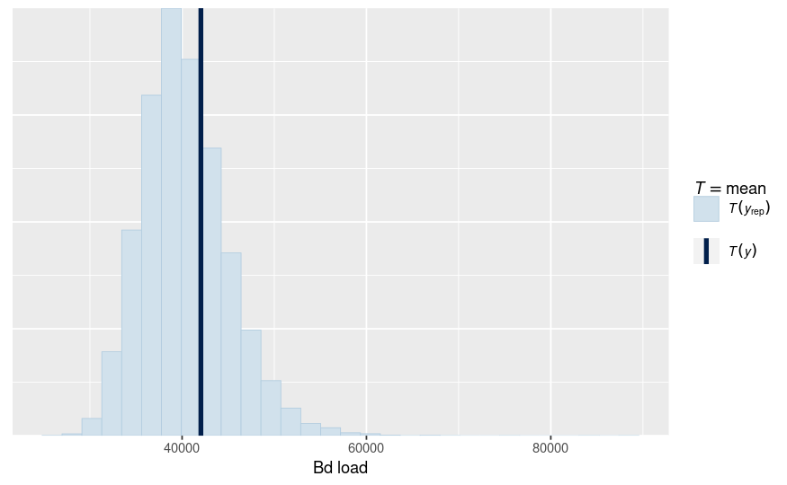

```r
pp_check(m1b, plotfun = "stat") +
    xlab("Bd load")
```

#### Calculate loo

```r
loo_m1b <- loo(m1b, cores = 4, save_psis = TRUE)
print(loo_m1b)
```

```
Computed from 20000 by 1841 log-likelihood matrix
```

|  | Estimate | SE |
| --- | --- | --- |
| elpd_loo | -18331.8 | 150.4 |
| p_loo | 176.8 | 9.8 |
| looic | 36663.5 | 300.8 |

```
------
Monte Carlo SE of elpd_loo is NA.

Pareto k diagnostic values:
                         Count Pct.    Min. n_eff
(-Inf, 0.5]   (good)     1503  81.6%   6622
 (0.5, 0.7]   (ok)        246  13.4%   663
   (0.7, 1]   (bad)        84   4.6%   62
   (1, Inf)   (very bad)    8   0.4%   33
See help('pareto-k-diagnostic') for details.
```

#### Posterior analysis

```r
tidy(m1b, conf.int = TRUE, conf.level = 0.90)
```

| term | estimate | std.error | conf.low | conf.high |
| --- | --- | --- | --- | --- |
| (Intercept) | 10.1388443 | 0.07587176 | 10.0134122 | 10.2624966 |
| after_c | 0.5404335 | 0.12410568 | 0.3334453 | 0.7408384 |

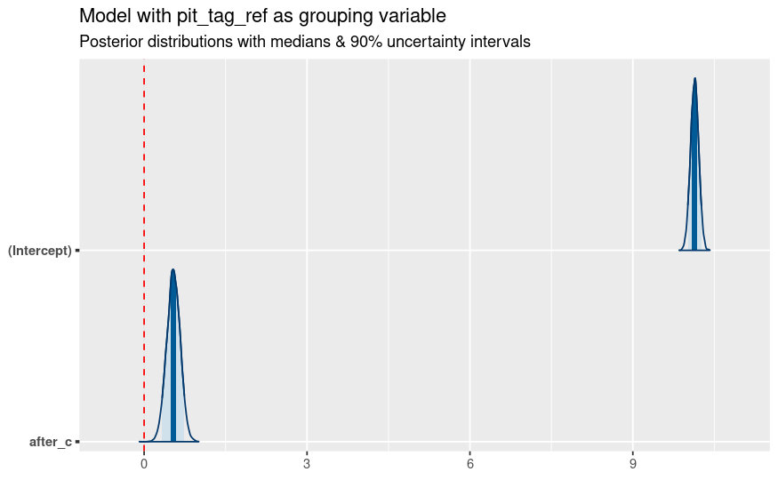

```r
mcmc_areas(m1b, area_method = "equal height", prob = 0.90, pars = b1) +
  geom_vline(xintercept = 0, color = "red", linetype = "dashed", lwd = 0.5) +
  ggtitle("Model with pit_tag_ref as grouping variable",
          "Posterior distributions with medians & 90% uncertainty intervals")
```

```r
# mean(bayes_R2(m1b))
```

### Model with 2 grouping variables: pit_tag_ref nested within translocation_id

#### Model specification

```r
m1c <- stan_glmer(
  bd_load ~ after_c + (1 | pit_tag_ref) + (1 | translocation_id),
  data = d2,
  family = neg_binomial_2(),
  chains = 4,
  iter = 5000*2,
  cores = 4,
  seed = 84735)
```

```
starting worker pid=45983 on localhost:11146 at 21:55:24.325
starting worker pid=46012 on localhost:11146 at 21:55:24.455
starting worker pid=46041 on localhost:11146 at 21:55:24.585
starting worker pid=46070 on localhost:11146 at 21:55:24.713
```

#### Priors and chain diagnostics

```r
prior_summary(m1c)
```

```
Priors for model 'm1c'
------
Intercept (after predictors centered)
 ~ normal(location = 0, scale = 2.5)

Coefficients
  Specified prior:
    ~ normal(location = 0, scale = 2.5)
  Adjusted prior:
    ~ normal(location = 0, scale = 5.1)

Auxiliary (reciprocal_dispersion)
 ~ exponential(rate = 1)

Covariance
 ~ decov(reg. = 1, conc. = 1, shape = 1, scale = 1)
------
See help('prior_summary.stanreg') for more details
```

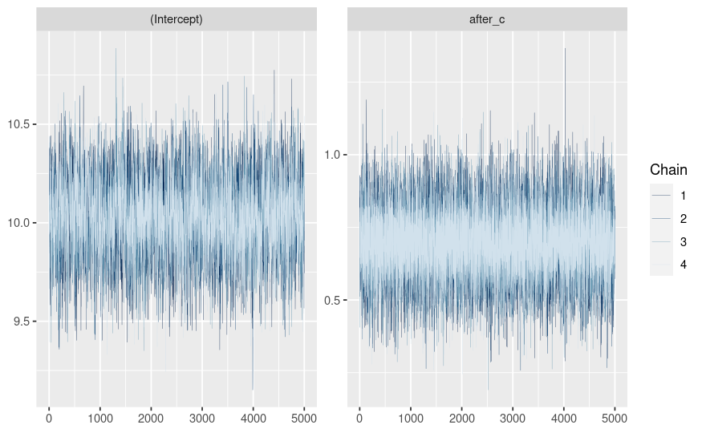

```r
b1 <- c("(Intercept)", "after_c")

mcmc_trace(m1c, size = 0.1, pars = b1)
```

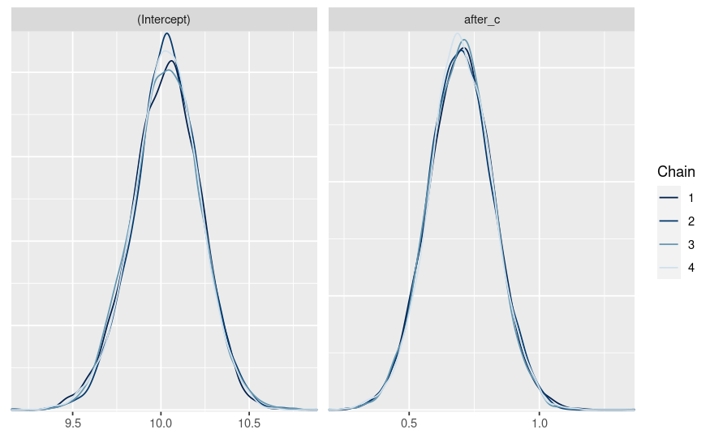

```r
mcmc_dens_overlay(m1c, pars = b1)
```

```r
summary(m1c)
```

```
Model Info:
 function:     stan_glmer
 family:       neg_binomial_2 [log]
 formula:      bd_load ~ after_c + (1 | pit_tag_ref) + (1 | translocation_id)
 algorithm:    sampling
 sample:       20000 (posterior sample size)
 priors:       see help('prior_summary')
 observations: 1841
 groups:       pit_tag_ref (767), translocation_id (24)

Estimates:
                                                  mean   sd   10%   50%   90%
(Intercept)                                     10.0    0.2  9.8  10.0  10.3
after_c                                          0.7    0.1  0.5   0.7   0.9
b[(Intercept) pit_tag_ref:062374570]             0.3    0.5 -0.4   0.3   1.0
b[(Intercept) pit_tag_ref:080045534]            -0.2    0.6 -1.0  -0.3   0.5
b[(Intercept) pit_tag_ref:080045779]            -0.1    0.7 -0.9  -0.1   0.8
b[(Intercept) pit_tag_ref:080047783]            -0.1    0.7 -0.9  -0.1   0.8
b[(Intercept) pit_tag_ref:080048769]             0.6    0.5 -0.1   0.5   1.2
b[(Intercept) pit_tag_ref:080048850]             0.0    0.6 -0.8   0.0   0.9
b[(Intercept) pit_tag_ref:080050269]            -0.3    0.7 -1.1  -0.3   0.6
b[(Intercept) pit_tag_ref:080050325]             0.4    0.6 -0.3   0.4   1.1
b[(Intercept) pit_tag_ref:080051294]            -0.2    0.6 -1.0  -0.2   0.6
b[(Intercept) pit_tag_ref:080052585]             0.0    0.6 -0.7   0.0   0.8
b[(Intercept) pit_tag_ref:080053099]            -0.1    0.7 -1.0  -0.1   0.8
b[(Intercept) pit_tag_ref:080054113]            -0.3    0.6 -1.1  -0.3   0.5
b[(Intercept) pit_tag_ref:080054873]             0.3    0.6 -0.4   0.3   1.1
b[(Intercept) pit_tag_ref:080055025]            -0.1    0.7 -0.9  -0.1   0.8
b[(Intercept) pit_tag_ref:080055046]             0.8    0.5  0.2   0.8   1.5
b[(Intercept) pit_tag_ref:080055334]             0.3    0.6 -0.4   0.3   1.0
b[(Intercept) pit_tag_ref:080058043]            -0.2    0.7 -1.1  -0.2   0.7
b[(Intercept) pit_tag_ref:080058318]            -0.3    0.7 -1.2  -0.3   0.5
b[(Intercept) pit_tag_ref:080058516]            -0.1    0.7 -1.0  -0.1   0.8
b[(Intercept) pit_tag_ref:080068126]             0.6    0.5 -0.1   0.6   1.3
b[(Intercept) pit_tag_ref:080374566]             0.4    0.5 -0.2   0.4   1.1
b[(Intercept) pit_tag_ref:090852530]             0.0    0.6 -0.7   0.0   0.8
b[(Intercept) pit_tag_ref:090867313]             0.1    0.6 -0.6   0.1   0.9
b[(Intercept) pit_tag_ref:090871274]             0.1    0.6 -0.7   0.1   0.9
b[(Intercept) pit_tag_ref:090873349]            -0.2    0.7 -1.1  -0.2   0.7
b[(Intercept) pit_tag_ref:090876364]             0.3    0.6 -0.4   0.3   1.0
```

[output cut: 503 more lines]

```
b[(Intercept) pit_tag_ref:900067000114018]       0.0  1.0 38852
b[(Intercept) pit_tag_ref:900067000114046]       0.0  1.0 38327
b[(Intercept) pit_tag_ref:900067000114081]       0.0  1.0 38453
b[(Intercept) pit_tag_ref:900067000114082]       0.0  1.0 33039
b[(Intercept) pit_tag_ref:900067000114084]       0.0  1.0 39780
b[(Intercept) pit_tag_ref:900067000114085]       0.0  1.0 40012
b[(Intercept) pit_tag_ref:900067000114087]       0.0  1.0 30114
b[(Intercept) pit_tag_ref:900067000114088]       0.0  1.0 38009
b[(Intercept) pit_tag_ref:900067000114089]       0.0  1.0 38512
b[(Intercept) pit_tag_ref:900067000114090]       0.0  1.0 39204
b[(Intercept) pit_tag_ref:900067000114091]       0.0  1.0 37623
b[(Intercept) pit_tag_ref:900067000114092]       0.0  1.0 36926
 [ reached getOption("max.print") -- omitted 465 rows ]

For each parameter, mcse is Monte Carlo standard error, n_eff is a crude measure of effective sample size, and Rhat is the potential scale reduction factor on split chains (at convergence Rhat=1).
```

#### Posterior predictive check

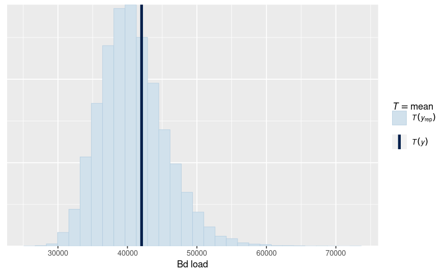

```r
pp_check(m1c, plotfun = "stat") +
    xlab("Bd load")
```

- Posterior predictive distribution implied by regression model closely matches original data (based on mean Bd load).

#### Calculate loo

```r
loo_m1c <- loo(m1c, cores = 4, save_psis = TRUE)
print(loo_m1c)
```

```
Computed from 20000 by 1841 log-likelihood matrix
```

|  | Estimate | SE |
| --- | --- | --- |
| elpd_loo | -18287.5 | 149.7 |
| p_loo | 124.1 | 9.1 |
| looic | 36575.0 | 299.4 |

```
------
Monte Carlo SE of elpd_loo is NA.

Pareto k diagnostic values:
                         Count Pct.    Min. n_eff
(-Inf, 0.5]   (good)     1674  90.9%   7899
 (0.5, 0.7]   (ok)        128   7.0%   1009
   (0.7, 1]   (bad)        37   2.0%   85
   (1, Inf)   (very bad)    2   0.1%   11
See help('pareto-k-diagnostic') for details.
```

#### Posterior analysis

```r
tidy(m1c, conf.int = TRUE, conf.level = 0.90)
```

| term | estimate | std.error | conf.low | conf.high |
| --- | --- | --- | --- | --- |
| (Intercept) | 10.0338504 | 0.1885054 | 9.7043991 | 10.3409108 |
| after_c | 0.6981164 | 0.1234459 | 0.4931836 | 0.9036882 |

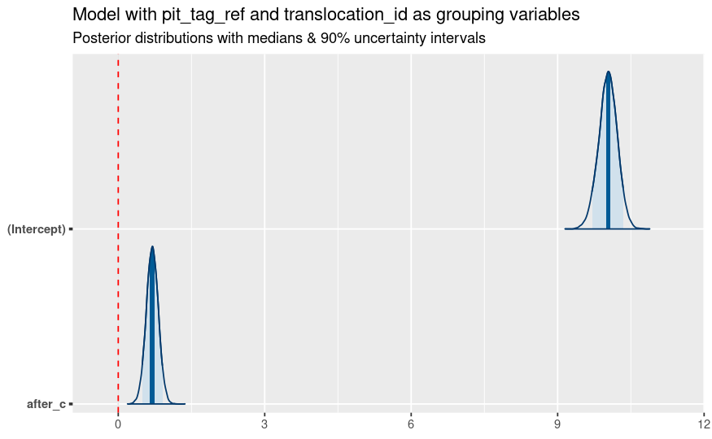

```r
mcmc_areas(m1c, area_method = "equal height", prob = 0.90, pars = b1) +
  geom_vline(xintercept = 0, color = "red", linetype = "dashed", lwd = 0.5) +
  ggtitle("Model with pit_tag_ref and translocation_id as grouping variables",
          "Posterior distributions with medians & 90% uncertainty intervals")
```

```r
# mean(bayes_R2(m1c))
```

### Model with 2 grouping variables: pit_tag_ref nested within site_id1

#### Model specification

```r
m1d <- stan_glmer(
  bd_load ~ after_c + (1 | pit_tag_ref) + (1 | site_id1),
  data = d2,
  family = neg_binomial_2(),
  chains = 4,
  iter = 5000*2,
  cores = 4,
  seed = 84735)
```

```
starting worker pid=47884 on localhost:11146 at 21:59:34.591
starting worker pid=47913 on localhost:11146 at 21:59:34.719
starting worker pid=47942 on localhost:11146 at 21:59:34.850
starting worker pid=47971 on localhost:11146 at 21:59:34.976
```

#### Priors and chain diagnostics

```r
prior_summary(m1d)
```

```
Priors for model 'm1d'
------
Intercept (after predictors centered)
 ~ normal(location = 0, scale = 2.5)

Coefficients
  Specified prior:
    ~ normal(location = 0, scale = 2.5)
  Adjusted prior:
    ~ normal(location = 0, scale = 5.1)

Auxiliary (reciprocal_dispersion)
 ~ exponential(rate = 1)

Covariance
 ~ decov(reg. = 1, conc. = 1, shape = 1, scale = 1)
------
See help('prior_summary.stanreg') for more details
```

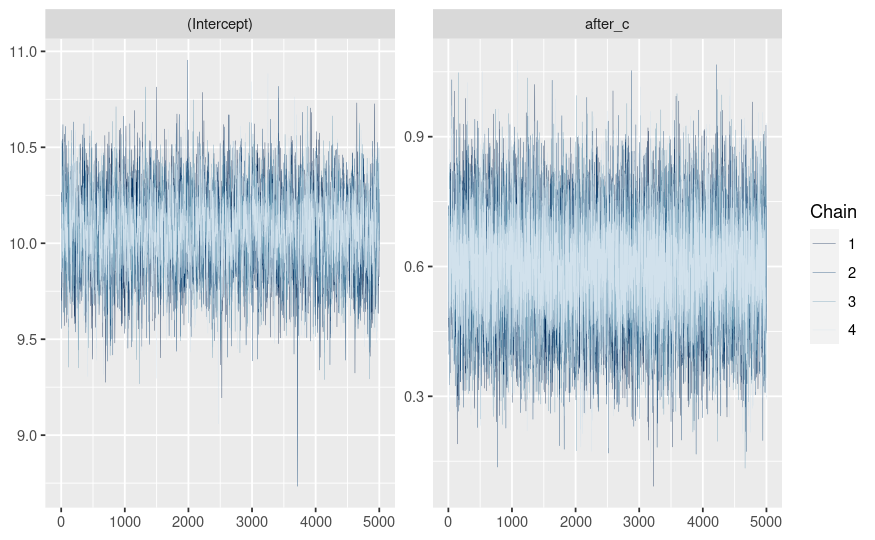

```r
b1 <- c("(Intercept)", "after_c")

mcmc_trace(m1d, size = 0.1, pars = b1)
```

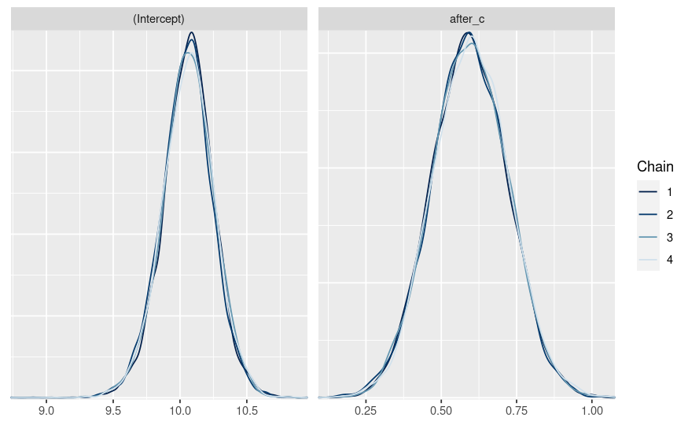

```r
mcmc_dens_overlay(m1d, pars = b1)
```

```r
summary(m1d)
```

```
Model Info:
 function:     stan_glmer
 family:       neg_binomial_2 [log]
 formula:      bd_load ~ after_c + (1 | pit_tag_ref) + (1 | site_id1)
 algorithm:    sampling
 sample:       20000 (posterior sample size)
 priors:       see help('prior_summary')
 observations: 1841
 groups:       pit_tag_ref (767), site_id1 (12)

Estimates:
                                             mean   sd   10%   50%   90%
(Intercept)                                10.1    0.2  9.8  10.1  10.3
after_c                                     0.6    0.1  0.4   0.6   0.8
b[(Intercept) pit_tag_ref:062374570]        0.4    0.6 -0.3   0.4   1.2
b[(Intercept) pit_tag_ref:080045534]       -0.3    0.7 -1.2  -0.3   0.6
b[(Intercept) pit_tag_ref:080045779]       -0.1    0.9 -1.2  -0.1   1.0
b[(Intercept) pit_tag_ref:080047783]       -0.1    0.9 -1.2  -0.1   1.0
b[(Intercept) pit_tag_ref:080048769]        0.8    0.6  0.0   0.7   1.5
b[(Intercept) pit_tag_ref:080048850]        0.1    0.8 -0.9   0.1   1.1
b[(Intercept) pit_tag_ref:080050269]       -0.4    0.8 -1.4  -0.4   0.7
b[(Intercept) pit_tag_ref:080050325]        0.5    0.7 -0.3   0.5   1.4
b[(Intercept) pit_tag_ref:080051294]       -0.2    0.7 -1.2  -0.3   0.7
b[(Intercept) pit_tag_ref:080052585]        0.1    0.7 -0.8   0.0   1.0
b[(Intercept) pit_tag_ref:080053099]       -0.1    0.9 -1.2  -0.1   1.0
b[(Intercept) pit_tag_ref:080054113]       -0.4    0.8 -1.4  -0.4   0.6
b[(Intercept) pit_tag_ref:080054873]        0.4    0.7 -0.5   0.4   1.4
b[(Intercept) pit_tag_ref:080055025]       -0.1    0.8 -1.1  -0.1   1.0
b[(Intercept) pit_tag_ref:080055046]        1.1    0.6  0.3   1.1   1.9
b[(Intercept) pit_tag_ref:080055334]        0.4    0.7 -0.4   0.4   1.3
b[(Intercept) pit_tag_ref:080058043]       -0.4    0.9 -1.5  -0.4   0.8
b[(Intercept) pit_tag_ref:080058318]       -0.5    0.9 -1.6  -0.5   0.6
b[(Intercept) pit_tag_ref:080058516]       -0.2    0.9 -1.3  -0.2   0.9
b[(Intercept) pit_tag_ref:080068126]        0.8    0.6  0.0   0.8   1.6
b[(Intercept) pit_tag_ref:080374566]        0.6    0.6 -0.2   0.5   1.4
b[(Intercept) pit_tag_ref:090852530]        0.1    0.7 -0.8   0.1   1.0
b[(Intercept) pit_tag_ref:090867313]        0.3    0.7 -0.6   0.2   1.2
b[(Intercept) pit_tag_ref:090871274]        0.1    0.8 -0.9   0.1   1.1
b[(Intercept) pit_tag_ref:090873349]       -0.3    0.9 -1.4  -0.3   0.8
b[(Intercept) pit_tag_ref:090876364]        0.5    0.7 -0.4   0.4   1.3
```

[output cut: 503 more lines]

```
b[(Intercept) pit_tag_ref:900067000114018]  0.0  1.0 29694
b[(Intercept) pit_tag_ref:900067000114046]  0.0  1.0 27166
b[(Intercept) pit_tag_ref:900067000114081]  0.0  1.0 30104
b[(Intercept) pit_tag_ref:900067000114082]  0.0  1.0 27219
b[(Intercept) pit_tag_ref:900067000114084]  0.0  1.0 27530
b[(Intercept) pit_tag_ref:900067000114085]  0.0  1.0 28750
b[(Intercept) pit_tag_ref:900067000114087]  0.0  1.0 22054
b[(Intercept) pit_tag_ref:900067000114088]  0.0  1.0 31903
b[(Intercept) pit_tag_ref:900067000114089]  0.0  1.0 31091
b[(Intercept) pit_tag_ref:900067000114090]  0.0  1.0 28157
b[(Intercept) pit_tag_ref:900067000114091]  0.0  1.0 31261
b[(Intercept) pit_tag_ref:900067000114092]  0.0  1.0 30488
 [ reached getOption("max.print") -- omitted 453 rows ]

For each parameter, mcse is Monte Carlo standard error, n_eff is a crude measure of effective sample size, and Rhat is the potential scale reduction factor on split chains (at convergence Rhat=1).
```

#### Posterior predictive check

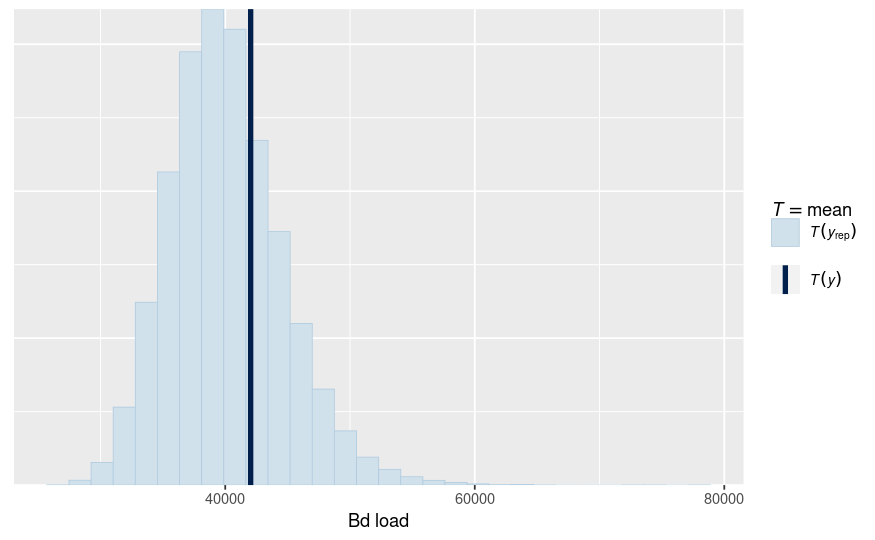

```r
pp_check(m1d, plotfun = "stat") +
    xlab("Bd load")
```

- Posterior predictive distribution implied by regression model closely matches original data (based on mean Bd load).

#### Calculate loo

```r
loo_m1d <- loo(m1d, cores = 4, save_psis = TRUE)
print(loo_m1d)
```

```
Computed from 20000 by 1841 log-likelihood matrix
```

|  | Estimate | SE |
| --- | --- | --- |
| elpd_loo | -18318.6 | 149.8 |
| p_loo | 148.5 | 9.4 |
| looic | 36637.3 | 299.7 |

```
------
Monte Carlo SE of elpd_loo is NA.

Pareto k diagnostic values:
                         Count Pct.    Min. n_eff
(-Inf, 0.5]   (good)     1584  86.0%   3880
 (0.5, 0.7]   (ok)        199  10.8%   564
   (0.7, 1]   (bad)        53   2.9%   83
   (1, Inf)   (very bad)    5   0.3%   27
See help('pareto-k-diagnostic') for details.
```

#### Posterior analysis

```r
tidy(m1d, conf.int = TRUE, conf.level = 0.90)
```

| term | estimate | std.error | conf.low | conf.high |
| --- | --- | --- | --- | --- |
| (Intercept) | 10.0635400 | 0.1859484 | 9.7327450 | 10.3712857 |
| after_c | 0.5950667 | 0.1265171 | 0.3899602 | 0.8005195 |

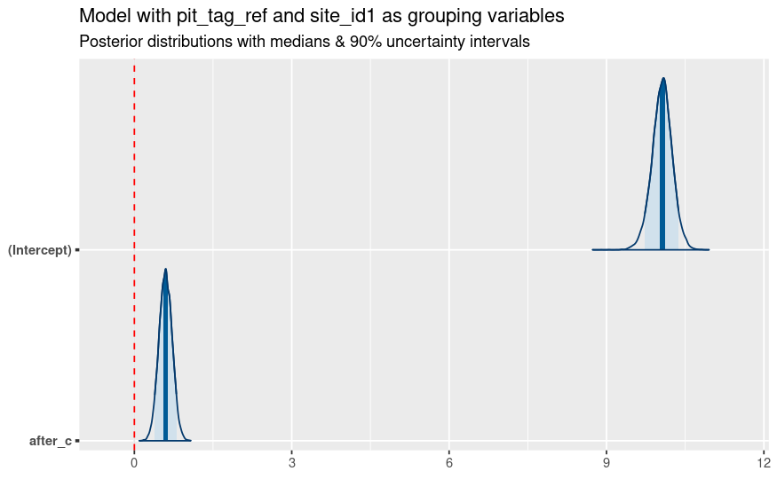

```r
mcmc_areas(m1d, area_method = "equal height", prob = 0.90, pars = b1) +
  geom_vline(xintercept = 0, color = "red", linetype = "dashed", lwd = 0.5) +
  ggtitle("Model with pit_tag_ref and site_id1 as grouping variables",
          "Posterior distributions with medians & 90% uncertainty intervals")
```

```r
# mean(bayes_R2(m1d))
```

### Compare 4 models with different grouping structures

```r
loo_compare(loo_m1a, loo_m1b, loo_m1c, loo_m1d)
```

```
    elpd_diff se_diff
m1c    0.0       0.0
m1d  -31.1       7.7
m1b  -44.2       9.6
m1a -162.8      21.4
```

## ANALYSIS 2: Evaluate effect of frog size independent of donor population

- Model m1d from `translocation_survival_analysis.Rmd` but using data subset where donor = 72996 only.

### Read in frog translocation dataset

- arm package used to rescale continuous variables (substract mean, divide by 2 SD), manual centering of binary variables.

```r
d1 <- read_csv(here::here("data", "clean", "frog_translocation_final.csv")) %>%
  drop_na(bd_load) %>%  # drop 12 records where bd_load is NA (9 are from 70413)
  mutate(
    first = if_else(order == 1, 1, 0),
    surv = if_else(survival < 0.5, 0, 1),
    male = if_else(sex == "m", 1, 0),
    elev_lo = if_else(elevation < 3020, 1, 0), # using interval defined by cut_interval, n = 2
    elev_z = arm::rescale(elevation),
    snowt_z = arm::rescale(snow_t),
    snowt1_z = arm::rescale(snow_t1),
    day_z = arm::rescale(day),
    length_z = arm::rescale(length),
    bdload_l = log10(bd_load + 1),
    bdload_z = arm::rescale(bdload_l),
    shore_c = shore - mean(shore),
    male_c = male - mean(male),
    elevlo_c = elev_lo - mean(elev_lo),
    first_c = first - mean(first),
    across(c(shore_c, male_c, elevlo_c, first_c), round, 3),
    across(c(site_id, shore_c, first_c, donor, male_c, elevlo_c, year), as.factor),
    surv = as.integer(surv))
# Add a descriptive translocation_id
d1 <- d1 %>%
  distinct(site_id, year) %>%
  arrange(site_id, year) %>%
  group_by(site_id) %>%
  mutate(transno = seq_len(n())) %>%
  ungroup(site_id) %>%
  unite(translocation_id, c("site_id", "transno"), remove = FALSE) %>%
  select(-transno) %>%
  mutate(translocation_id = as.factor(translocation_id)) %>%
  inner_join(d1, by = c("site_id", "year")) %>%
  relocate(translocation_id, .after = site_id)
```

### Model specification

```r
d1_72996 <- d1 %>%
  filter(donor == "72996" & !is.na(bd_load))

m1d_72996 <- stan_glmer(
  surv ~ length_z + snowt_z + snowt1_z + day_z + bdload_z + elev_z + first_c + male_c + (1 | translocation_id),
  data = d1_72996,
  family = binomial,
  chains = 4,
  iter = 5000*2,
  cores = 4,
  seed = 84735)
```

```
starting worker pid=48626 on localhost:11146 at 22:03:43.275
starting worker pid=48655 on localhost:11146 at 22:03:43.418
starting worker pid=48684 on localhost:11146 at 22:03:43.560
starting worker pid=48713 on localhost:11146 at 22:03:43.687
```

### Priors & chain diagnostics

```r
prior_summary(m1d_72996)
```

```
Priors for model 'm1d_72996'
------
Intercept (after predictors centered)
 ~ normal(location = 0, scale = 2.5)

Coefficients
  Specified prior:
    ~ normal(location = [0,0,0,...], scale = [2.5,2.5,2.5,...])
  Adjusted prior:
    ~ normal(location = [0,0,0,...], scale = [6.39,4.90,4.89,...])

Covariance
 ~ decov(reg. = 1, conc. = 1, shape = 1, scale = 1)
------
See help('prior_summary.stanreg') for more details
```

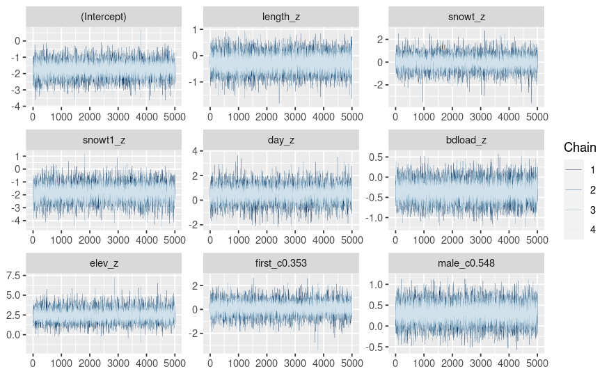

```r
b1_72996 <- c("(Intercept)", "length_z", "snowt_z", "snowt1_z", "day_z", "bdload_z", "elev_z", "first_c0.353", "male_c0.548")

mcmc_trace(m1d_72996, size = 0.1, pars = b1_72996)
```

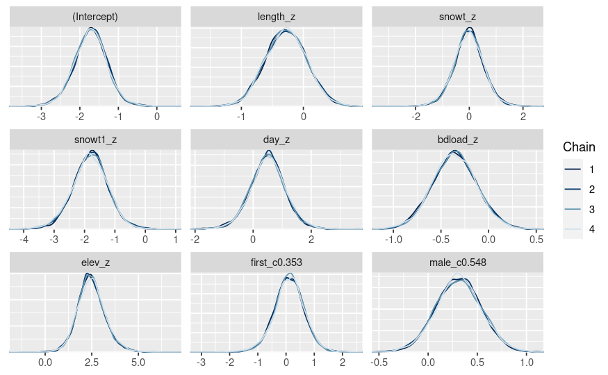

```r
mcmc_dens_overlay(m1d_72996, pars = b1_72996)
```

```r
summary(m1d_72996)
```

```
Model Info:
 function:     stan_glmer
 family:       binomial [logit]
 formula:      surv ~ length_z + snowt_z + snowt1_z + day_z + bdload_z + elev_z +
       first_c + male_c + (1 | translocation_id)
 algorithm:    sampling
 sample:       20000 (posterior sample size)
 priors:       see help('prior_summary')
 observations: 613
 groups:       translocation_id (17)

Estimates:
                                                  mean   sd   10%   50%   90%
(Intercept)                                     -1.7    0.4 -2.3  -1.7  -1.2
length_z                                        -0.3    0.3 -0.7  -0.3   0.1
snowt_z                                          0.0    0.6 -0.7   0.0   0.7
snowt1_z                                        -1.8    0.6 -2.6  -1.8  -1.1
day_z                                            0.5    0.6 -0.3   0.5   1.3
bdload_z                                        -0.4    0.2 -0.7  -0.4  -0.1
elev_z                                           2.5    0.7  1.6   2.4   3.4
first_c0.353                                     0.1    0.5 -0.6   0.1   0.8
male_c0.548                                      0.3    0.2  0.0   0.3   0.6
b[(Intercept) translocation_id:70134_1]         -0.6    0.5 -1.3  -0.6   0.0
b[(Intercept) translocation_id:70370_1]         -0.2    0.8 -1.1  -0.2   0.7
b[(Intercept) translocation_id:70370_2]          0.1    0.7 -0.8   0.1   0.9
b[(Intercept) translocation_id:70414_1]         -0.5    0.8 -1.5  -0.4   0.5
b[(Intercept) translocation_id:70449_1]          0.2    0.7 -0.7   0.2   1.1
b[(Intercept) translocation_id:70449_2]          1.3    0.6  0.6   1.3   2.1
b[(Intercept) translocation_id:70505_1]          0.5    0.6 -0.2   0.5   1.2
b[(Intercept) translocation_id:70505_2]          0.1    0.6 -0.6   0.1   0.9
b[(Intercept) translocation_id:70505_3]          0.3    0.7 -0.5   0.3   1.2
b[(Intercept) translocation_id:70505_4]         -0.3    0.6 -1.0  -0.3   0.5
b[(Intercept) translocation_id:70550_1]          0.2    0.5 -0.5   0.1   0.8
b[(Intercept) translocation_id:70550_2]         -0.5    0.6 -1.3  -0.5   0.3
b[(Intercept) translocation_id:70619_1]         -0.5    0.6 -1.2  -0.5   0.1
b[(Intercept) translocation_id:70628_1]          0.3    0.6 -0.4   0.3   1.1
b[(Intercept) translocation_id:70641_1]          0.4    0.7 -0.4   0.4   1.3
b[(Intercept) translocation_id:70641_2]         -0.3    0.6 -1.1  -0.3   0.5
b[(Intercept) translocation_id:70641_3]         -0.8    0.7 -1.7  -0.7   0.0
Sigma[translocation_id:(Intercept),(Intercept)]  0.8    0.6  0.3   0.6   1.5
```

[output cut: 25 more lines]

```
b[(Intercept) translocation_id:70505_2]         0.0  1.0  20891
b[(Intercept) translocation_id:70505_3]         0.0  1.0  23230
b[(Intercept) translocation_id:70505_4]         0.0  1.0  19453
b[(Intercept) translocation_id:70550_1]         0.0  1.0  14128
b[(Intercept) translocation_id:70550_2]         0.0  1.0  16223
b[(Intercept) translocation_id:70619_1]         0.0  1.0  15636
b[(Intercept) translocation_id:70628_1]         0.0  1.0  13273
b[(Intercept) translocation_id:70641_1]         0.0  1.0  12646
b[(Intercept) translocation_id:70641_2]         0.0  1.0  20299
b[(Intercept) translocation_id:70641_3]         0.0  1.0  16719
Sigma[translocation_id:(Intercept),(Intercept)] 0.0  1.0   7424
mean_PPD                                        0.0  1.0  20714
log-posterior                                   0.1  1.0   5432

For each parameter, mcse is Monte Carlo standard error, n_eff is a crude measure of effective sample size, and Rhat is the potential scale reduction factor on split chains (at convergence Rhat=1).
```

### Posterior predictive check

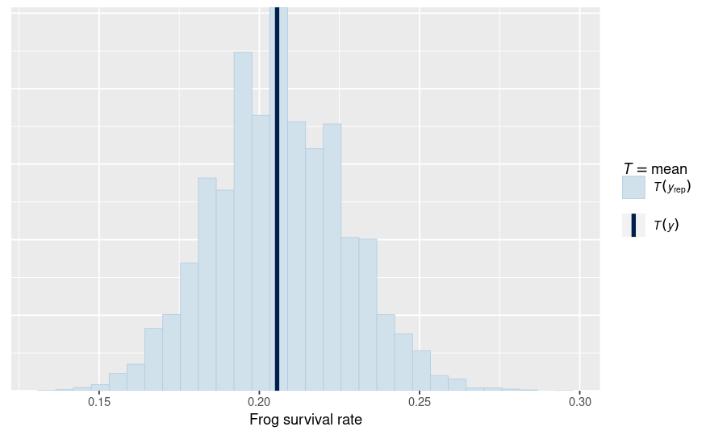

```r
pp_check(m1d_72996, plotfun = "stat") +
    xlab("Frog survival rate")
```

### Posterior analysis

```r
tidy(m1d_72996, conf.int = TRUE, conf.level = 0.90)
```

| term | estimate | std.error | conf.low | conf.high |
| --- | --- | --- | --- | --- |
| (Intercept) | -1.71553585 | 0.4106655 | -2.43718281 | -1.03286829 |
| length_z | -0.27952082 | 0.3353586 | -0.82533440 | 0.26849274 |
| snowt_z | -0.01493674 | 0.5271934 | -0.94074389 | 0.90005297 |
| snowt1_z | -1.79948878 | 0.5596253 | -2.79914781 | -0.86859647 |
| day_z | 0.50752982 | 0.5714290 | -0.50276777 | 1.49777492 |
| bdload_z | -0.35686445 | 0.2327438 | -0.74288077 | 0.03520267 |
| elev_z | 2.44430875 | 0.6898302 | 1.33427869 | 3.75102636 |
| first_c0.353 | 0.11871680 | 0.5025968 | -0.77355324 | 0.96819287 |
| male_c0.548 | 0.31117793 | 0.2293677 | -0.06946555 | 0.68873558 |

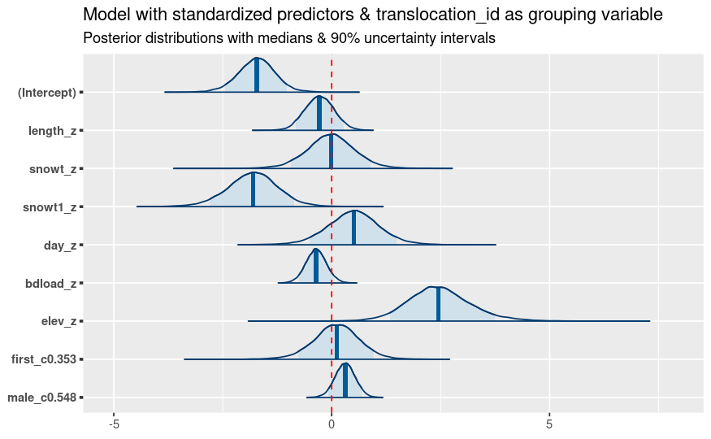

```r
mcmc_areas(m1d_72996, area_method = "equal height", prob = 0.90, pars = b1_72996) +
  geom_vline(xintercept = 0, color = "red", linetype = "dashed", lwd = 0.5) +
  ggtitle("Model with standardized predictors & translocation_id as grouping variable",
          "Posterior distributions with medians & 90% uncertainty intervals")
```

```r
mean(bayes_R2(m1d_72996))
```

```
[1] 0.2050799
```

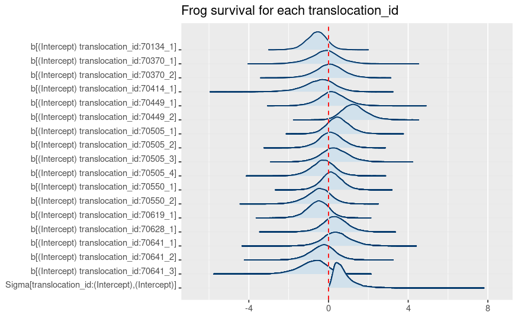

```r
# Frog survival by translocation_id
mcmc_areas_ridges(m1d_72996, regex_pars = "translocation_id") +
  geom_vline(xintercept = 0, color = "red", linetype = "dashed", lwd = 0.5) +
  ggtitle("Frog survival for each translocation_id")
```

## ANALYSIS 3: Assess effect on m1d of including all records, including where bd_load = NA

- Additional analysis of model m1d from `translocation_survival_analysis.Rmd`.

### Read in frog translocation dataset

- arm package used to rescale continuous variables (substract mean, divide by 2 SD), manual centering of binary variables.

```r
d1_allna <- read_csv(here::here("data", "clean", "frog_translocation_final.csv")) %>%
  mutate(
    first = if_else(order == 1, 1, 0),
    surv = if_else(survival < 0.5, 0, 1),
    male = if_else(sex == "m", 1, 0),
    elev_lo = if_else(elevation < 3020, 1, 0), # using interval defined by cut_interval, n = 2
    elev_z = arm::rescale(elevation),
    snowt_z = arm::rescale(snow_t),
    snowt1_z = arm::rescale(snow_t1),
    day_z = arm::rescale(day),
    length_z = arm::rescale(length),
    bdload_l = log10(bd_load + 1),
    bdload_z = arm::rescale(bdload_l),
    shore_c = shore - mean(shore),
    male_c = male - mean(male),
    elevlo_c = elev_lo - mean(elev_lo),
    first_c = first - mean(first),
    across(c(shore_c, male_c, elevlo_c, first_c), round, 3),
    across(c(site_id, shore_c, first_c, donor, male_c, elevlo_c, year), as.factor),
    surv = as.integer(surv))
# Add a descriptive translocation_id
d1_allna <- d1_allna %>%
  distinct(site_id, year) %>%
  arrange(site_id, year) %>%
  group_by(site_id) %>%
  mutate(transno = seq_len(n())) %>%
  ungroup(site_id) %>%
  unite(translocation_id, c("site_id", "transno"), remove = FALSE) %>%
  select(-transno) %>%
  mutate(translocation_id = as.factor(translocation_id)) %>%
  inner_join(d1_allna, by = c("site_id", "year")) %>%
  relocate(translocation_id, .after = site_id)
```

### Model specification

```r
m1d_allna <- stan_glmer(
  surv ~ length_z + snowt_z + snowt1_z + day_z + elev_z + first_c + male_c + donor + (1 | translocation_id),
  data = d1_allna,
  family = binomial,
  chains = 4,
  iter = 5000*2,
  cores = 4,
  seed = 84735)
```

```
starting worker pid=49094 on localhost:11146 at 22:04:22.195
starting worker pid=49123 on localhost:11146 at 22:04:22.339
starting worker pid=49152 on localhost:11146 at 22:04:22.486
starting worker pid=49181 on localhost:11146 at 22:04:22.613
```

### List model variable names

```r
get_variables(m1d_allna)
```

```
 [1] "(Intercept)"                                     "length_z"                                        "snowt_z"                                         "snowt1_z"                                        "day_z"                                           "elev_z"
 [7] "first_c0.349"                                    "male_c0.549"                                     "donor70567"                                      "donor72996"                                      "b[(Intercept) translocation_id:70134_1]"         "b[(Intercept) translocation_id:70370_1]"
[13] "b[(Intercept) translocation_id:70370_2]"         "b[(Intercept) translocation_id:70413_1]"         "b[(Intercept) translocation_id:70413_2]"         "b[(Intercept) translocation_id:70413_3]"         "b[(Intercept) translocation_id:70414_1]"         "b[(Intercept) translocation_id:70449_1]"
[19] "b[(Intercept) translocation_id:70449_2]"         "b[(Intercept) translocation_id:70505_1]"         "b[(Intercept) translocation_id:70505_2]"         "b[(Intercept) translocation_id:70505_3]"         "b[(Intercept) translocation_id:70505_4]"         "b[(Intercept) translocation_id:70550_1]"
[25] "b[(Intercept) translocation_id:70550_2]"         "b[(Intercept) translocation_id:70556_1]"         "b[(Intercept) translocation_id:70556_2]"         "b[(Intercept) translocation_id:70619_1]"         "b[(Intercept) translocation_id:70628_1]"         "b[(Intercept) translocation_id:70641_1]"
[31] "b[(Intercept) translocation_id:70641_2]"         "b[(Intercept) translocation_id:70641_3]"         "b[(Intercept) translocation_id:74976_1]"         "b[(Intercept) translocation_id:74976_2]"         "Sigma[translocation_id:(Intercept),(Intercept)]" "accept_stat__"
[37] "stepsize__"                                      "treedepth__"                                     "n_leapfrog__"                                    "divergent__"                                     "energy__"
```

### Priors & chain diagnostics

```r
prior_summary(m1d_allna)
```

```
Priors for model 'm1d_allna'
------
Intercept (after predictors centered)
 ~ normal(location = 0, scale = 2.5)

Coefficients
  Specified prior:
    ~ normal(location = [0,0,0,...], scale = [2.5,2.5,2.5,...])
  Adjusted prior:
    ~ normal(location = [0,0,0,...], scale = [5.00,5.00,5.00,...])

Covariance
 ~ decov(reg. = 1, conc. = 1, shape = 1, scale = 1)
------
See help('prior_summary.stanreg') for more details
```

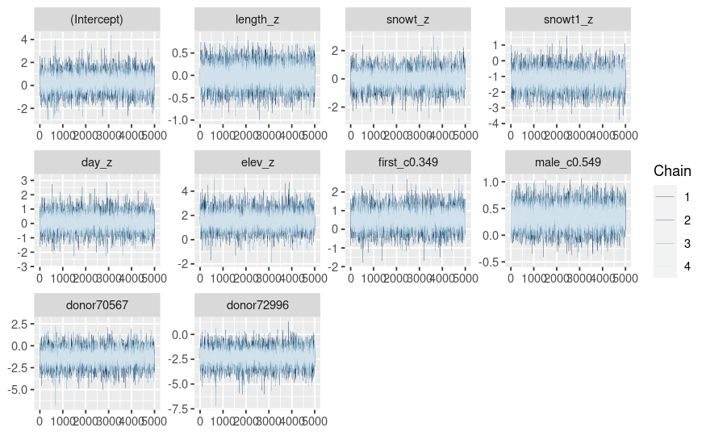

```r
b1_allna <- c("(Intercept)", "length_z", "snowt_z", "snowt1_z", "day_z", "elev_z", "first_c0.349", "male_c0.549", "donor70567", "donor72996")

mcmc_trace(m1d_allna, size = 0.1, pars = b1_allna)
```

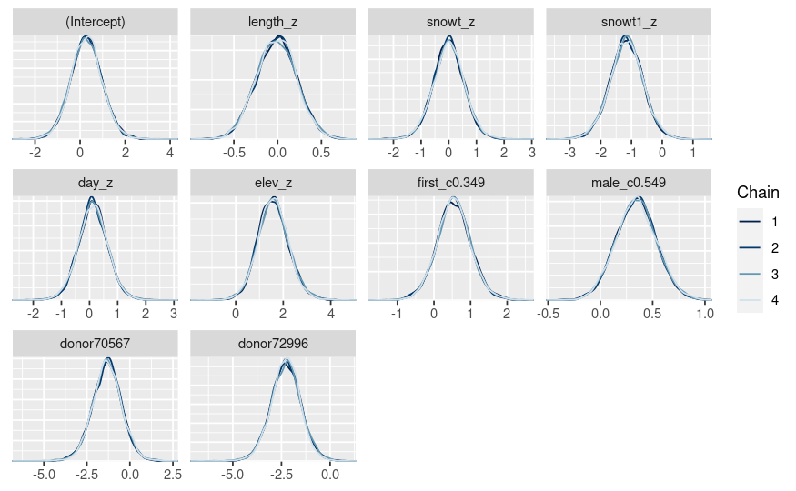

```r
mcmc_dens_overlay(m1d_allna, pars = b1_allna)
```

```r
summary(m1d_allna)
```

```
Model Info:
 function:     stan_glmer
 family:       binomial [logit]
 formula:      surv ~ length_z + snowt_z + snowt1_z + day_z + elev_z + first_c +
       male_c + donor + (1 | translocation_id)
 algorithm:    sampling
 sample:       20000 (posterior sample size)
 priors:       see help('prior_summary')
 observations: 779
 groups:       translocation_id (24)

Estimates:
                                                  mean   sd   10%   50%   90%
(Intercept)                                      0.3    0.7 -0.6   0.3   1.2
length_z                                         0.0    0.2 -0.3   0.0   0.3
snowt_z                                          0.0    0.6 -0.7   0.0   0.7
snowt1_z                                        -1.2    0.6 -1.9  -1.2  -0.5
day_z                                            0.1    0.5 -0.6   0.1   0.8
elev_z                                           1.6    0.7  0.8   1.6   2.4
first_c0.349                                     0.5    0.5  0.0   0.5   1.1
male_c0.549                                      0.3    0.2  0.1   0.3   0.6
donor70567                                      -1.3    0.9 -2.4  -1.3  -0.3
donor72996                                      -2.3    0.8 -3.3  -2.3  -1.3
b[(Intercept) translocation_id:70134_1]         -0.6    0.5 -1.2  -0.6   0.1
b[(Intercept) translocation_id:70370_1]         -0.5    0.8 -1.5  -0.5   0.4
b[(Intercept) translocation_id:70370_2]          0.0    0.8 -0.9   0.0   1.0
b[(Intercept) translocation_id:70413_1]         -0.2    0.7 -1.1  -0.1   0.7
b[(Intercept) translocation_id:70413_2]          0.4    0.7 -0.5   0.4   1.3
b[(Intercept) translocation_id:70413_3]         -0.3    0.8 -1.2  -0.3   0.7
b[(Intercept) translocation_id:70414_1]         -0.9    0.8 -2.0  -0.9   0.1
b[(Intercept) translocation_id:70449_1]          0.2    0.6 -0.7   0.1   1.0
b[(Intercept) translocation_id:70449_2]          1.6    0.6  0.9   1.6   2.4
b[(Intercept) translocation_id:70505_1]          0.1    0.5 -0.6   0.1   0.8
b[(Intercept) translocation_id:70505_2]          0.1    0.6 -0.7   0.1   0.9
b[(Intercept) translocation_id:70505_3]          0.1    0.7 -0.8   0.1   1.0
b[(Intercept) translocation_id:70505_4]         -0.1    0.6 -0.9  -0.1   0.6
b[(Intercept) translocation_id:70550_1]          0.5    0.5 -0.2   0.5   1.2
b[(Intercept) translocation_id:70550_2]         -0.1    0.6 -0.9  -0.1   0.6
b[(Intercept) translocation_id:70556_1]         -0.5    0.7 -1.4  -0.5   0.4
b[(Intercept) translocation_id:70556_2]         -0.8    0.7 -1.8  -0.8   0.1
```

[output cut: 41 more lines]

```
b[(Intercept) translocation_id:70550_2]         0.0  1.0  15656
b[(Intercept) translocation_id:70556_1]         0.0  1.0  14838
b[(Intercept) translocation_id:70556_2]         0.0  1.0  15698
b[(Intercept) translocation_id:70619_1]         0.0  1.0  13397
b[(Intercept) translocation_id:70628_1]         0.0  1.0  12793
b[(Intercept) translocation_id:70641_1]         0.0  1.0  11505
b[(Intercept) translocation_id:70641_2]         0.0  1.0  20516
b[(Intercept) translocation_id:70641_3]         0.0  1.0  18061
b[(Intercept) translocation_id:74976_1]         0.0  1.0  14320
b[(Intercept) translocation_id:74976_2]         0.0  1.0  15463
Sigma[translocation_id:(Intercept),(Intercept)] 0.0  1.0   8148
mean_PPD                                        0.0  1.0  20140
log-posterior                                   0.1  1.0   5721

For each parameter, mcse is Monte Carlo standard error, n_eff is a crude measure of effective sample size, and Rhat is the potential scale reduction factor on split chains (at convergence Rhat=1).
```

### Posterior predictive check

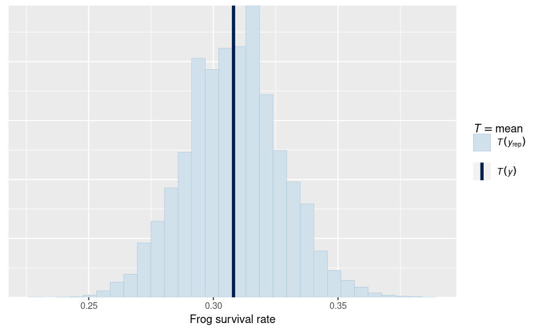

```r
pp_check(m1d_allna, plotfun = "stat") +
    xlab("Frog survival rate")
```

### Posterior analysis

```r
tidy(m1d_allna, conf.int = TRUE, conf.level = 0.90)
```

| term | estimate | std.error | conf.low | conf.high |
| --- | --- | --- | --- | --- |
| (Intercept) | 0.2780590317 | 0.6857980 | -0.87138999 | 1.45471750 |
| length_z | -0.0106806022 | 0.2313707 | -0.39129671 | 0.36936889 |
| snowt_z | 0.0003802563 | 0.5393506 | -0.92622966 | 0.91689191 |
| snowt1_z | -1.1611243571 | 0.5318692 | -2.07859797 | -0.26926748 |
| day_z | 0.1194631647 | 0.5092333 | -0.74471918 | 0.99200833 |
| elev_z | 1.5674448756 | 0.6336411 | 0.53474085 | 2.68720979 |
| first_c0.349 | 0.5394824779 | 0.4475523 | -0.22597437 | 1.32643268 |
| male_c0.549 | 0.3435279905 | 0.1937868 | 0.01943636 | 0.66772683 |
| donor70567 | -1.3195842087 | 0.8278157 | -2.74224186 | 0.07694843 |
| donor72996 | -2.2657063490 | 0.7527935 | -3.57019546 | -1.00328701 |

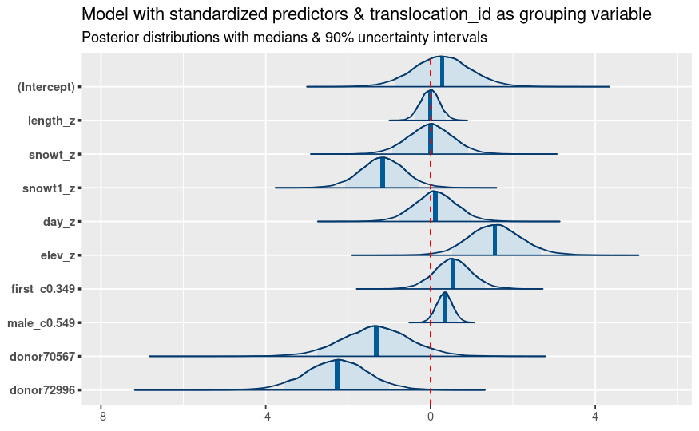

```r
mcmc_areas(m1d_allna, area_method = "equal height", prob = 0.90, pars = b1_allna) +
  geom_vline(xintercept = 0, color = "red", linetype = "dashed", lwd = 0.5) +
  ggtitle("Model with standardized predictors & translocation_id as grouping variable",
          "Posterior distributions with medians & 90% uncertainty intervals")
```

```r
mean(bayes_R2(m1d_allna))
```

```
[1] 0.3150276
```

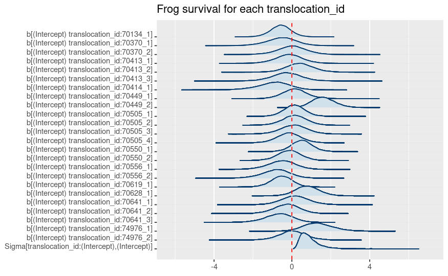

```r
# Frog survival by translocation_id
mcmc_areas_ridges(m1d_allna, regex_pars = "translocation_id") +
  geom_vline(xintercept = 0, color = "red", linetype = "dashed", lwd = 0.5) +
  ggtitle("Frog survival for each translocation_id")
```

- Inclusion of all records (i.e., 12 records where bd_load = NA that were excluded in primary analysis) did not change the results.